# Exploratory Analisys Data in R

2025-02-11

## What is Exploratory Data Analysis (EDA)?

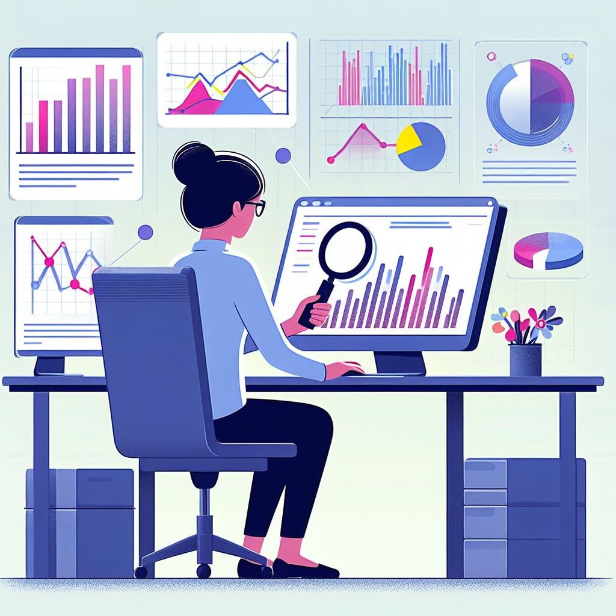

Usually…

[figure not shown]

But, we don’t leave the **“route”**. So, what if my colleague wants to reproduce my analysis and results?

In *R* (a script), we can clearly show this **“route”**…

[figure not shown]

Good lecture about [Reproducible Science](https://theness.com/neurologicablog/science-we-have-a-reproducibility-problem/)

Exploratory Data Analysis (EDA) involves summarizing and visualizing datasets to uncover insights. Key steps include:

1. **Data Overview:** Understanding data types, structure, and missing values using `str()` and `summary()`.
2. **Data Cleaning:** Handling missing data, correcting errors, and standardizing values.
3. **Identifying Patterns:** Detecting relationships, clusters, or anomalies for hypothesis generation.
4. **Visualizations:** Plotting histograms, scatter plots, and box plots to identify trends and outliers.
5. **Descriptive Statistics:** Calculating means, medians, and standard deviations for quantitative variables.

## Data set example

- Loading the `palmerpenguins` dataset

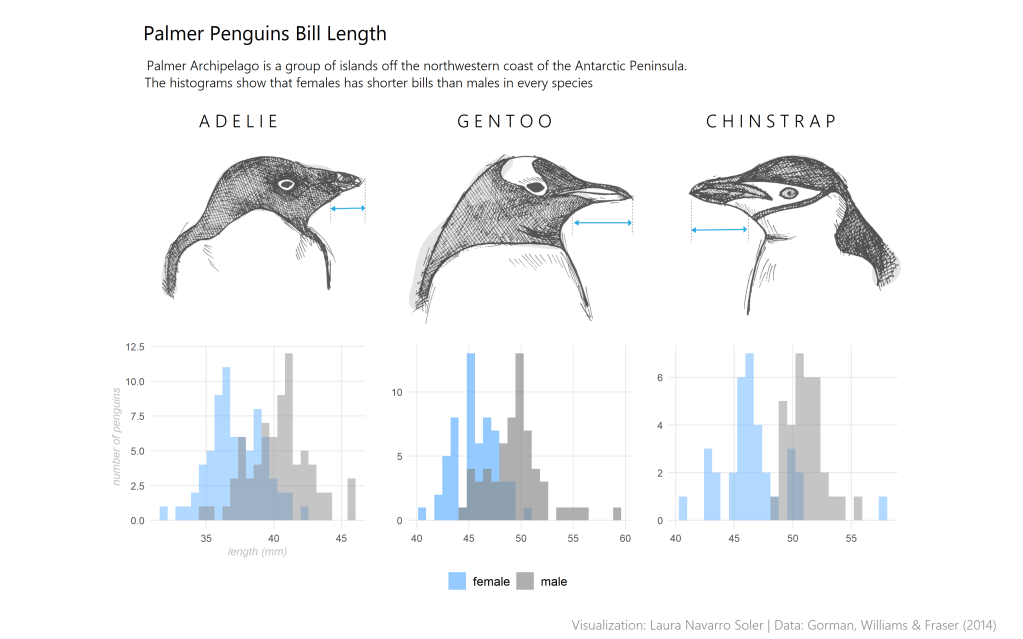

Where this data was obtained…

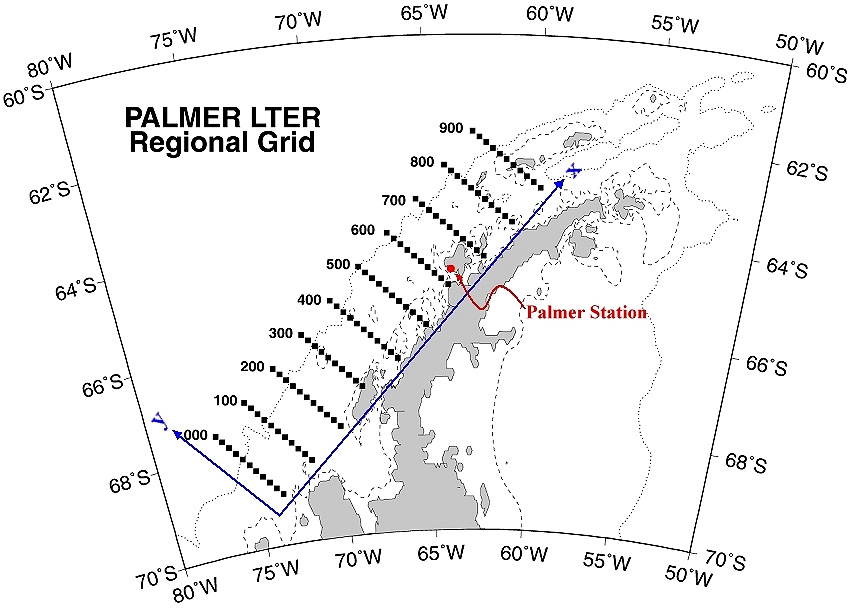

## The `penguins` Dataset

```r
# Load the data
library(palmerpenguins)
library(kableExtra)
data("penguins")
```

## Basic Data Exploration

```r
# Check dimensions and structure
dim(penguins)
```

```
## [1] 344   8
```

```r
str(penguins)
```

```
## tibble [344 × 8] (S3: tbl_df/tbl/data.frame)
##  $ species          : Factor w/ 3 levels "Adelie","Chinstrap",..: 1 1 1 1 1 1 1 1 1 1 ...
##  $ island           : Factor w/ 3 levels "Biscoe","Dream",..: 3 3 3 3 3 3 3 3 3 3 ...
##  $ bill_length_mm   : num [1:344] 39.1 39.5 40.3 NA 36.7 39.3 38.9 39.2 34.1 42 ...
##  $ bill_depth_mm    : num [1:344] 18.7 17.4 18 NA 19.3 20.6 17.8 19.6 18.1 20.2 ...
##  $ flipper_length_mm: int [1:344] 181 186 195 NA 193 190 181 195 193 190 ...
##  $ body_mass_g      : int [1:344] 3750 3800 3250 NA 3450 3650 3625 4675 3475 4250 ...
##  $ sex              : Factor w/ 2 levels "female","male": 2 1 1 NA 1 2 1 2 NA NA ...
##  $ year             : int [1:344] 2007 2007 2007 2007 2007 2007 2007 2007 2007 2007 ...
```

## Summary Statistics

```r
# Quick statistical overview
summary(penguins)
```

```
##       species          island    bill_length_mm  bill_depth_mm
##  Adelie   :152   Biscoe   :168   Min.   :32.10   Min.   :13.10
##  Chinstrap: 68   Dream    :124   1st Qu.:39.23   1st Qu.:15.60
##  Gentoo   :124   Torgersen: 52   Median :44.45   Median :17.30
##                                  Mean   :43.92   Mean   :17.15
##                                  3rd Qu.:48.50   3rd Qu.:18.70
##                                  Max.   :59.60   Max.   :21.50
##                                  NA's   :2       NA's   :2
##  flipper_length_mm  body_mass_g       sex           year
##  Min.   :172.0     Min.   :2700   female:165   Min.   :2007
##  1st Qu.:190.0     1st Qu.:3550   male  :168   1st Qu.:2007
##  Median :197.0     Median :4050   NA's  : 11   Median :2008
##  Mean   :200.9     Mean   :4202                Mean   :2008
##  3rd Qu.:213.0     3rd Qu.:4750                3rd Qu.:2009
##  Max.   :231.0     Max.   :6300                Max.   :2009
##  NA's   :2         NA's   :2
```

## Central Tendency

- **Mean:** average value
- **Median:** middle value
- **Mode:** most frequent value

```r
mean(penguins$bill_length_mm, na.rm = TRUE)
```

```
## [1] 43.92193
```

```r
median(penguins$bill_length_mm, na.rm = TRUE)
```

```
## [1] 44.45
```

## Variability

- **Range:** difference between max and min
- **Variance:** spread of the data
- **Standard deviation:** square root of variance

```r
range(penguins$bill_length_mm, na.rm = TRUE)
```

```
## [1] 32.1 59.6
```

```r
var(penguins$bill_length_mm, na.rm = TRUE)
```

```
## [1] 29.80705
```

```r
sd(penguins$bill_length_mm, na.rm = TRUE)
```

```
## [1] 5.459584
```

## Grouped Summaries

```r
# Grouped mean by species
library(dplyr)
penguins %>%
  group_by(species) %>%
  summarise(mean_bill_length = mean(bill_length_mm, na.rm = TRUE))
```

```
## # A tibble: 3 × 2
##   species   mean_bill_length
##   <fct>                <dbl>
## 1 Adelie                38.8
## 2 Chinstrap             48.8
## 3 Gentoo                47.5
```

## Correlation

```r
cor(penguins$bill_length_mm,
    penguins$bill_depth_mm,
    use = "complete.obs")
```

```
## [1] -0.2350529
```

## Conclusion

- Descriptive statistics are fundamental for understanding data.
- R provides powerful tools to calculate, visualize, and interpret data patterns.

## Hand on!

- This class will cover:
  - Data manipulation
  - Descriptive statistics
  - Multivariate statistics…
  - Run this [code](https://github.com/MauroMardones/Course_R_Statistics/blob/main/scripts/02-EDA.R)